# Assn03

Darren Clark

21/11/2020

# Predicting Electric Space Heating

Because NB Power has consumption data readily available for all customers from our billing system, we can analyze these consumption patterns to determine the likelihood of a customer having electric heat.

First we must set our data set up. We will normalize consumption to 100 units over the course of the year and then use the monthly consumptions to predict the presence of electric space heating.

```r
data5 <- EPS[,c("Q41","Q59","Usage1","Usage2","Usage3","Usage4", "Usage5","Usage6","Usage7","Usage8","Usage9","Usage10","Usage11","Usage12","UsageTotal")]
#View(data5)

data5 <- data5 %>%
  filter(Q41 < 7.5) %>%
  filter(Q59 < 7.5) %>%
  filter(is.na(UsageTotal) == F)

#6761 obs.
data5$heat = if_else(data5$Q41==1,1,0)
data5$M1 = data5$Usage1 / data5$UsageTotal * 100
data5$M2 = data5$Usage2 / data5$UsageTotal * 100
data5$M3 = data5$Usage3 / data5$UsageTotal * 100
data5$M4 = data5$Usage4 / data5$UsageTotal * 100
data5$M5 = data5$Usage5 / data5$UsageTotal * 100
data5$M6 = data5$Usage6 / data5$UsageTotal * 100
data5$M7 = data5$Usage7 / data5$UsageTotal * 100
data5$M8 = data5$Usage8 / data5$UsageTotal * 100
data5$M9 = data5$Usage9 / data5$UsageTotal * 100
data5$M10 = data5$Usage10 / data5$UsageTotal * 100
data5$M11 = data5$Usage11 / data5$UsageTotal * 100
data5$M12 = data5$Usage12 / data5$UsageTotal * 100
data5$check = data5$M1 + data5$M2 + data5$M3 + data5$M4 + data5$M5 + data5$M6 + data5$M7 + data5$M8 + data5$M9 + data5$M10 + data5$M11 + data5$M12

#Apply bin function on home type (Q59A is designated as either a "Detached" home or an "Attached" home i.e. apartment, condo, row house, etc.)
data5$Q59A <- data5$Q59 %>%
  sapply(Q59_bin1) %>% as.factor()
data5$heat = if_else(data5$Q41==1,1,0)
```

Now I will create a logistic regression to predict electric heat. First I split my data into two groups: a training set and a test set (framework borrowed from datacamp). I will use this baseline for comparing to later with a full cross-validation.

```r
set.seed(33)
gp <- runif(nrow(data5))
data5_train <- data5[gp < 0.75, ]
data5_test <- data5[gp >= 0.75, ]

model4 <- glm(heat~M1+M2+M3+M4+M5+M6+M7+M8+M9+M10+M11+as.factor(Q59A), data = data5_train, family = binomial)
summary(model4)
```

```
##
## Call:
## glm(formula = heat ~ M1 + M2 + M3 + M4 + M5 + M6 + M7 + M8 +
##     M9 + M10 + M11 + as.factor(Q59A), family = binomial, data = data5_train)
##
## Deviance Residuals:
##     Min       1Q   Median       3Q      Max
## -3.5199  -0.7524   0.4826   0.7363   3.6112
##
## Coefficients:
##                         Estimate Std. Error z value Pr(>|z|)
## (Intercept)              3.86506    1.76630   2.188  0.02865 *
## M1                       0.01548    0.02656   0.583  0.56006
## M2                      -0.03520    0.03238  -1.087  0.27703
## M3                      -0.10964    0.03589  -3.055  0.00225 **
## M4                      -0.06588    0.03299  -1.997  0.04580 *
## M5                       0.01502    0.03745   0.401  0.68824
## M6                      -0.06120    0.03937  -1.555  0.12004
## M7                      -0.33720    0.04038  -8.351  < 2e-16 ***
## M8                      -0.01551    0.03161  -0.491  0.62375
## M9                       0.04040    0.03040   1.329  0.18382
## M10                      0.04091    0.02320   1.764  0.07780 .
## M11                      0.05416    0.03166   1.710  0.08718 .
## as.factor(Q59A)Detached -1.60714    0.13384 -12.008  < 2e-16 ***
## ---
## Signif. codes:  0 '***' 0.001 '**' 0.01 '*' 0.05 '.' 0.1 ' ' 1
##
## (Dispersion parameter for binomial family taken to be 1)
##
##     Null deviance: 6169.4  on 4846  degrees of freedom
## Residual deviance: 4743.8  on 4834  degrees of freedom
## AIC: 4769.8
##
## Number of Fisher Scoring iterations: 5
```

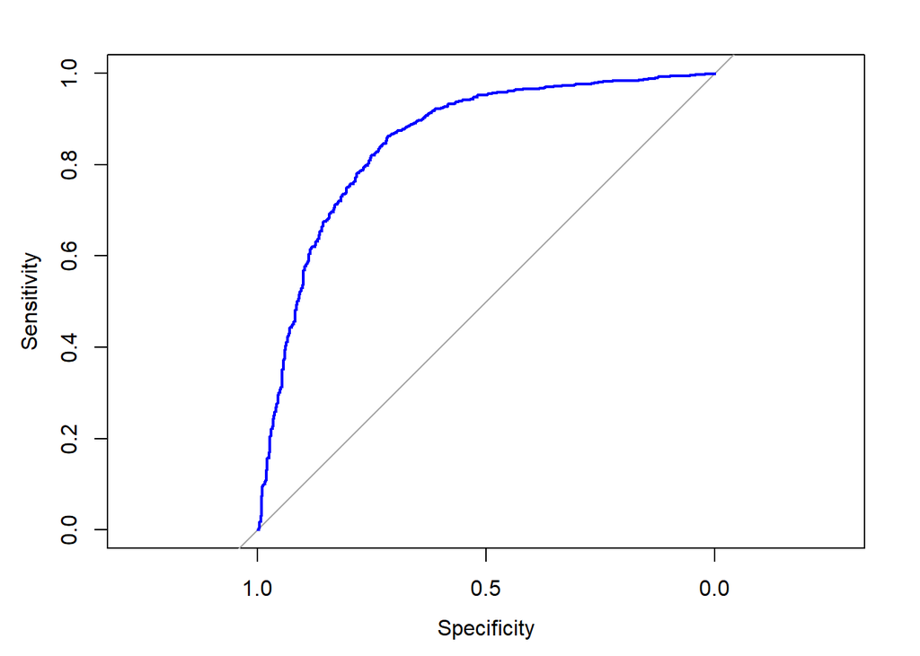

```r
data5_test$pred <- predict(model4, newdata = data5_test, type = "response")

# Examine ROC Curve
# Note that I installed this once, but now it gives me an error, so I commented
# it out.

# install.packages("pROC")

ROC <- roc(data5_test$heat, data5_test$pred)
plot(ROC, col = "blue")
```

```r
auc(ROC)
```

```
## Area under the curve: 0.8513
```

```r
# Another way to examine accuracy is simply by checking the test data for the
# correct assignments.  examine accuracy.
N = 0.5
data5_test$pred1 <- if_else(data5_test$pred > N, 1,0)
data5_test$accuracy <- if_else(data5_test$pred1 == data5_test$heat,1,0)
table(data5_test$accuracy)
```

```
##
##    0    1
##  301 1301
```

I also want to look at RMSE as this will be a comparator I rely on later.

```r
rmse(data5_test$pred,data5_test$heat)
```

```
## [1] 0.3775254
```

# Model refinement

Many of the monthly variables are not significant. This is likely because the impact of electric heating affects some months similarly and they would therfore be highly correlated. We will atempt to build a model with only two usage factors. One for winter load and one for summer load.

```r
set.seed(32)
data5$win <- (data5$M9 + data5$M10 + data5$M11 + data5$M12)/4
data5$sum <- (data5$M3 + data5$M4 + data5$M5 + data5$M6)/4

data5_train <- data5[gp < 0.75, ]
data5_test <- data5[gp >= 0.75, ]

model5 <- glm(heat~win+sum+as.factor(Q59A), data = data5_train, family = binomial)
summary(model5)
```

```
##
## Call:
## glm(formula = heat ~ win + sum + as.factor(Q59A), family = binomial,
##     data = data5_train)
##
## Deviance Residuals:
##     Min       1Q   Median       3Q      Max
## -3.5384  -0.8192   0.5002   0.7589   3.6194
##
## Coefficients:
##                         Estimate Std. Error z value Pr(>|z|)
## (Intercept)             -1.86435    0.72095  -2.586 0.009711 **
## win                      0.40820    0.03946  10.345  < 2e-16 ***
## sum                     -0.15485    0.04625  -3.348 0.000813 ***
## as.factor(Q59A)Detached -1.56356    0.13205 -11.840  < 2e-16 ***
## ---
## Signif. codes:  0 '***' 0.001 '**' 0.01 '*' 0.05 '.' 0.1 ' ' 1
##
## (Dispersion parameter for binomial family taken to be 1)
##
##     Null deviance: 6169.4  on 4846  degrees of freedom
## Residual deviance: 4863.4  on 4843  degrees of freedom
## AIC: 4871.4
##
## Number of Fisher Scoring iterations: 5
```

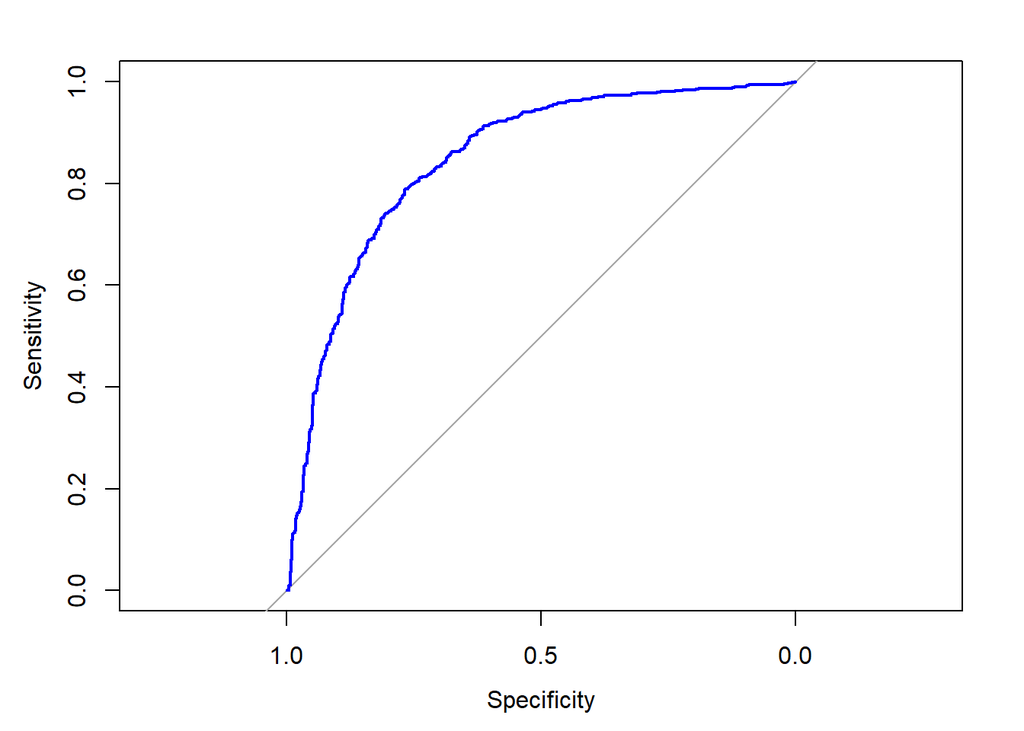

```r
# Each predictor is now significant

data5_test$pred <- predict(model5, newdata = data5_test, type = "response")

# Check ROC crve
set.seed(5)
ROC1 <- roc(data5_test$heat, data5_test$pred)
plot(ROC1, col = "blue")
```

```r
(auc(ROC1))
```

```
## Area under the curve: 0.8457
```

```r
(rmse(data5_test$heat, data5_test$pred))
```

```
## [1] 0.3832829
```

```r
N = 0.4

data5_test$pred1 <- if_else(data5_test$pred > N, 1,0)

data5_test$accuracy <- if_else(data5_test$pred1 == data5_test$heat,1,0)
table(data5_test$accuracy)
```

```
##
##    0    1
##  336 1266
```

```r
rmse(data5_test$accuracy,data5_test$heat)
```

```
## [1] 0.433463
```

The RMSE of this model is slightly higher than the model with all of the parameters still within. This could be the result of overfitting. WE will check this later. The next step is to refine the simplker model using k-fold cross validation.

# Step-wise model building using K-fold cross validation

```r
# Predict from a full model as a baseline

model <- glm(heat~win+sum+as.factor(Q59A), data = data5, family = binomial)
data5$pred <- predict(model, newdata = data5)
# Get the rmse of the full model's predictions
rmse(data5$pred,data5$heat)
```

```
## [1] 1.2767
```

```r
# Do 10-fold cross validation for the model.
set.seed(42)
nRows <- nrow(data5)
splitPlan <- kWayCrossValidation(nRows,10,NULL,NULL)
# str(splitPlan)

k <- 10 # Number of folds
data5$pred.cv <- 0
for(i in 1:k) {
  split <- splitPlan[[i]]
  model <- glm(heat~win+sum+as.factor(Q59A), data = data5[split$train, ], family = binomial)
data5$pred.cv[split$app] <- predict(model, newdata = data5[split$app, ])
}
# Get the rmse of the cross-validation predictions
rmse(data5$pred.cv, data5$heat)
```

```
## [1] 1.279253
```

```r
# The rmse is basically the same.
```

# Forward stepwise Model selection

We will build a model using forward stepwise method and validating iwth 10 fold cross validation. The structure is adapted from the Introduction to Statistical Learning tutorials foudn online at: https://www.r-bloggers.com/2014/09/in-depth-introduction-to-machine-learning-in-15-hours-of-expert-videos/

Note that this structure is for a linear model rather than a logistic model. I was unable to troubleshoot a logistic model without the examples provided in datacamp and from the ISL textbook website.

```r
data6 = data5[,c("heat","M1","M2","M3","M4","M5","M6","M7","M8","M9","M10","M11","Q59A")]
data6$Q59A <- if_else(data6$Q59A=="Attached",1,0)
set.seed(10)
folds=sample(rep(1:10,length=nrow(data6)))
table(folds)
```

```
## folds
##   1   2   3   4   5   6   7   8   9  10
## 645 645 645 645 645 645 645 645 645 644
```

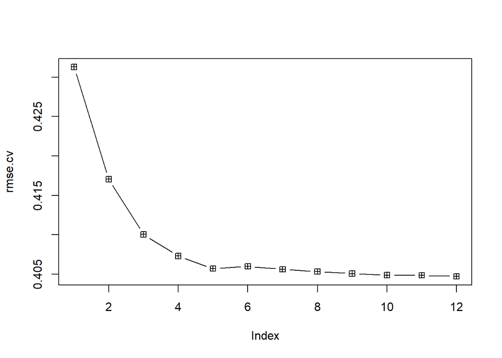

```r
cv.errors=matrix(NA,10,12)
# Write prediction method
predict.regsubsets=function(object,newdata,id,...){
  form=as.formula(object$call[[2]])
  mat=model.matrix(form,newdata)
  coefi=coef(object,id=id)
  mat[,names(coefi)]%*%coefi
}

for(k in 1:10){
  best.fit=regsubsets(heat~.,data=data6[folds!=k,],nvmax=12,method="forward")
  for(i in 1:12){
    pred=predict(best.fit,data6[folds==k,],id=i)
    cv.errors[k,i]=mean((data6$heat[folds==k]-pred)^2)
  }
}
rmse.cv=sqrt(apply(cv.errors,2,mean))
plot(rmse.cv,pch=12,type="b")
```

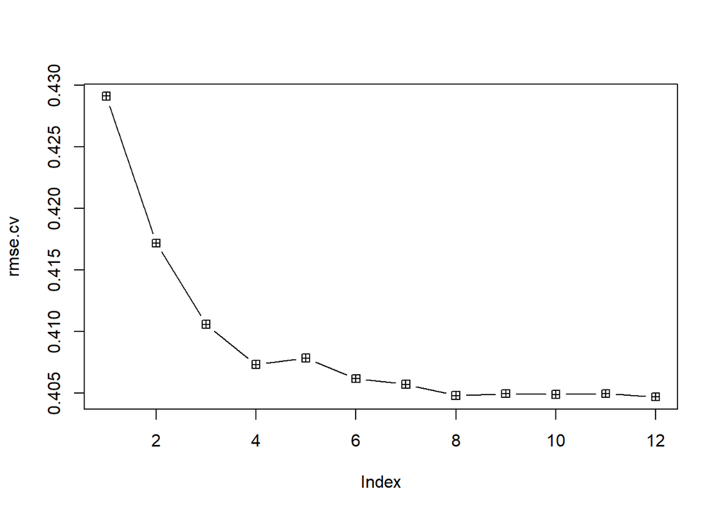

```r
# Compare to backward subset selection

for(k in 1:10){
  best.fit=regsubsets(heat~.,data=data6[folds!=k,],nvmax=12,method="backward")
  for(i in 1:12){
    pred=predict(best.fit,data6[folds==k,],id=i)
    cv.errors[k,i]=mean((data6$heat[folds==k]-pred)^2)
  }
}
rmse.cv=sqrt(apply(cv.errors,2,mean))
plot(rmse.cv,pch=12,type="b")
```

The forward stepwise regression with all 12 terms is identical to the model prepared in the first section, but gives a slightly worse RMSE. I believe this is the impact fo using a linear model for the step-wise regressions instead of a logistic regression. The relative accuracy of the model is, however likely to correlate to a logistic model, so it is likely that somewhere in the range of 5 to 7 terms is sufficient.

The forward step-wise model gets to a lower RMSE with fewer terms than the backward step-wise model, so in methods that would prioritize smaller models (Cp, Adj. R0square, etc.), this apprears to be giving better results than backward step-wise regression.

Overall, the model provides a reasonable assumption of accuracy, but is not perfect by any means. One explanation for this is that while the question of whether or not a home is heated with electric heat seems binary, it is actually more complex than that. Many homes have secondary heating system that could be electric or non-electric, so what we are actually measuring is the outcome of whether or not the customer self identified as using electricity as their primary heating fuel. That means if they used 51% electricity and 49% wood for fuel, they would respond as primarily electric, while if it were 49% electric and 51% wood, they would identify as non-electric. The self-identification process also assumes that the customer is knowledgeable enough to tell the difference. The survey contains additional level of detail on secondary heating systems, which I did not get into in detail, but in future analyses I would suggest exploring these. In subsequent analyses I also hypothesize that a nearest neighbours analysis may provide a good predictive analysis for these multiple degrees of electric heat.